# Fisher Attrition

This is an excercise in understanding how and when fishers dropped out of the fishery.

We have been told that the creation of the BRFA system in 1998 lead to a number of fishers, particularly old timers, leaving the fishery (Personal communication: Uncle Roy, Clay Tam…). Additionally fishers opperating from small boats, common in the fishery, were driven out because after their preffered fishing grounds were closed, their vessels were less capable moving to the next choicest fishing grounds.

The goal of this notebook is to use landing records from the commercial fishery’s to examine the annual rates at which fishers left the fishery to see if the year when the BRFA system was created and when it was restructured have annomolously high rates of attirition. We are also interested in determining if vessel size/fisher skill level significantly affected annual attrition.

We should first define some terms. Attrition year - the last year that a fisher was active in a fishery. Experience - The number of years that a fisher actively participated in the fishery (reported any landing).

We’ll now load relevant libraries and our commercial catch data.

```r
library(data.table) # uniqueN
library(MuMIn) #dredge
library(lme4) #glmer
library(tidyr) # gather()
```

Commercial catch data collected by the State of Hawaii’s Department of Land and Natural Resources’ Division of Aquatic Resources was provided to researchers under a MOU.

```r
load('/Volumes/KINGSTON/SRS_Mods/data/processed_data.RData')
if(is.factor(fdata$year)){fdata$year = as.numeric(levels(fdata$year)[fdata$year])}
# head(fdata) # Can't show this, it's confidential!
```

This data records a number of useful information. For this analysis, we are primarily concerned with the year in which fishing occurred, and the fisher’s first and last name. First and last name appear to be a better method for identifying individual fishers than the use of CMLs.

Data collection began in the late 1940s. First we create a data frame with information about the number of fishers participating each year and a breakdown of the fleet’s experience level each year.

While this analysis is written to be flexible, we will define fisher experience in 4 bins of 3 years (1-3 years experience, 4-6 years experience, 7-9 years experience, 10+ years experience).

What we get out of the following chunk is a data frame (attrition_df) where each row contains annual data with information in the following columns: year total_fishers experience_level{bin1} experience_level{bin2} … experience_level{binN} attritioning_fishers attritioning_fishers{bin1} attritioning_fishers{bin2} … attritioning_fishers{binN}

```r
## Defining Experience Bins
  max_experience = 10
  years_per_bin = 3
  experience_bins = seq(from = 1, to = max_experience, by = years_per_bin)

### Setting up our output data frame
## We start be defining our column names absed on our experience bins.
column_names = c('year', 'total_fishers', paste('exp_level', experience_bins[-length(experience_bins)], '-', experience_bins[-1], sep = ""), paste('exp_level', experience_bins[length(experience_bins)], "+", sep = ""), 'attritioning_fishers',  paste('attritioning_level', experience_bins[-length(experience_bins)], '-', experience_bins[-1], sep = ""), paste('attritioning_level', experience_bins[length(experience_bins)], "+", sep = ""))

## We then build our data frame from the number of columns and unique years in our data
attrition_df = as.data.frame(matrix(data  = 0, nrow = uniqueN(fdata$year), ncol = length(column_names)), stringsAsFactors = FALSE)
  colnames(attrition_df) = column_names
  attrition_df$year = sort(unique(fdata$year))

### We also need a list of what year did each fisher left the fishery (attrition year)
attrition_years = aggregate(fdata$year, by = list(fdata$fisher), FUN = max)
  colnames(attrition_years) = c('name', 'year')

## Now we loop through our years
for(current_year in sort(unique(fdata$year))){

## In a given year, how many people are fishing and what is there experience level?

## Getting list of fisher names, how many records we have for them
fisher_experience_at_year = aggregate(fdata$year[fdata$year <= current_year], by = list(fdata$fisher[fdata$year <= current_year]), FUN = uniqueN)
  colnames(fisher_experience_at_year) = c('fisher', 'current_experience')
current_experience_bin = 0

## Removing entries for fishers that are not currently fishing
fisher_experience_at_year = fisher_experience_at_year[fisher_experience_at_year$fisher %in% fdata$fisher[fdata$year == current_year], ]

## Assigning each fisher to an experience bin based on number of years fished
  # For example, if bins are defiend every 3 years, a 2 year fisher would be bin 1, a 4 year fisher is bin 2, etc...
for(j in 1:length(fisher_experience_at_year$current_experience)){
  fisher_experience_at_year$current_experience_bin[j] = length(which(fisher_experience_at_year$current_experience[j] >= experience_bins))
  }


## Noting which fishers are not returning by matching our fisher names to the names of those that report this as their last year
fisher_experience_at_year$attritioned = fisher_experience_at_year$fisher %in% attrition_years$name[which(attrition_years$year == current_year)]

# The number of fishers that year is the number of unique names filing reports that year

## Getting the number of fishers
# Total
  attrition_df$total_fishers[attrition_df$year == current_year] = length(unique(fdata$fisher[fdata$year == current_year]))

# In each experience bin
for(j in 1:length(experience_bins)){
  attrition_df[attrition_df$year == current_year, j + 2] = length(which(fisher_experience_at_year$current_experience_bin == j))
}

## Getting the number of those fishers that then attritioned
# Total
  attrition_df$attritioning_fishers[attrition_df$year == current_year] = sum(fisher_experience_at_year$attritioned)

# By experience level
for(j in 1:length(experience_bins)){
  attrition_df[attrition_df$year == current_year, j + 3 + length(experience_bins)] = length(which(fisher_experience_at_year$current_experience_bin == j & fisher_experience_at_year$attritioned == TRUE))
}
}


 attrition_df$attrition_rate = attrition_df$attritioning_fishers / attrition_df$total_fishers
```

### Visualization of Attrition Data

#### Fisher Participation

First lets look at the total number of fishers participating in the fishery in a given year

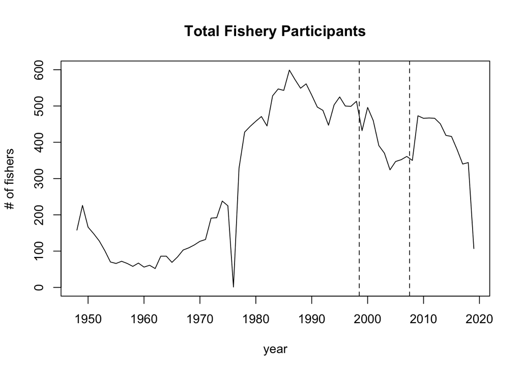

```r
{
plot(attrition_df$total_fishers ~ attrition_df$year, ylab = '# of fishers', xlab = 'year', type = 'l', main = 'Total Fishery Participants', ylim = c(0, 600))
abline(v = c(1998.5, 2007.5), col = 'black', lty = 2)
}
```

Vertical dashed lines indicate the period in time that the BRFAs were established/reorganized. Strangely we see a massive dip in the year 1976 which appears to be a data annomoly (only 1 fisher reported fishing?). We should ask Reggie about this.

We can clearly see a declining trend in fisher participation following enactment of the BRFAs.

Let’s also take a look at the skill breakdown each year

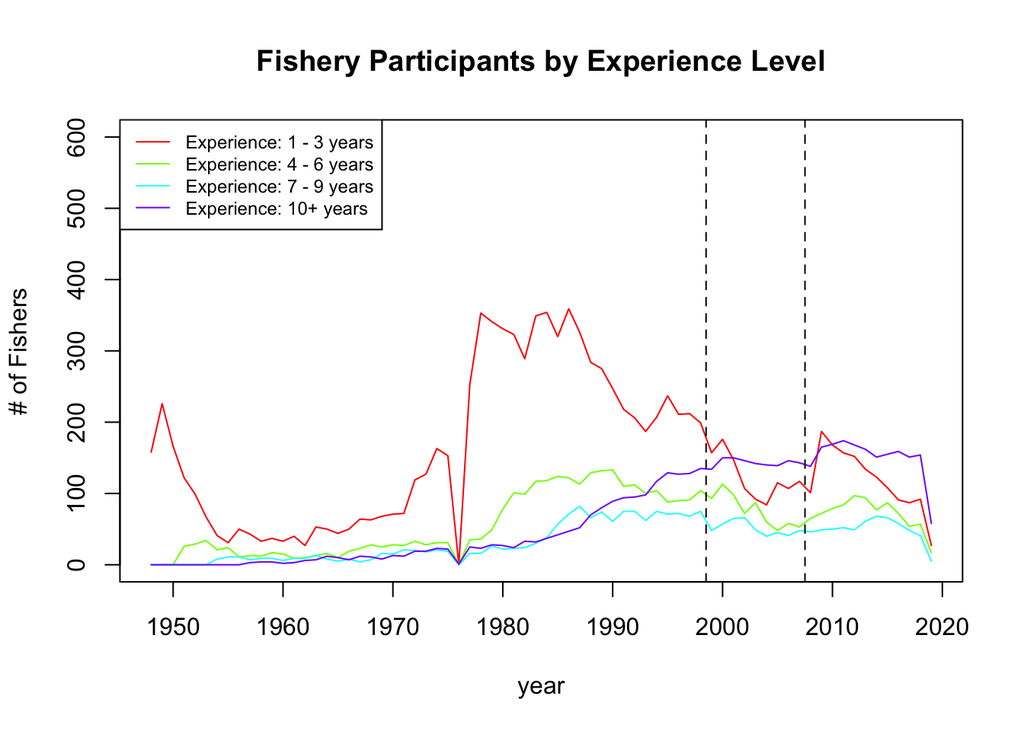

```r
{
plot(attrition_df$total_fishers ~ attrition_df$year, pch = 19, col = 'black', ylim = c(0, 600), type = 'n', ylab = '# of Fishers', xlab = 'year', main = 'Fishery Participants by Experience Level')
for(i in 1:length(experience_bins)){
  lines(attrition_df[, i + 2] ~ attrition_df$year, col = color_pal[i + 1])
  }
  legend('topleft', col = c(rainbow(length(experience_bins))), legend = c( paste('Experience:', experience_bins[-length(experience_bins)], '-', experience_bins[2:length(experience_bins)] - 1, 'years', sep = " "), paste('Experience: ', experience_bins[length(experience_bins)], '+ years', sep = "")), lty = 1, cex = .75)
abline(v = 1998.5, col = 'black', lty =  2)
abline(v = 2007.5, col = 'black', lty =  2)
}
```

#### Fisher Attrition

And now lets look at the number of fishers attritioning each year. As mentioned, the year of attrition is the last year that you reported fishing. If the BRFAs influnced attrition year, we would expect to see a spike before the dotted lines indicating that the year prior to the new regulations was the last year many fishers fished

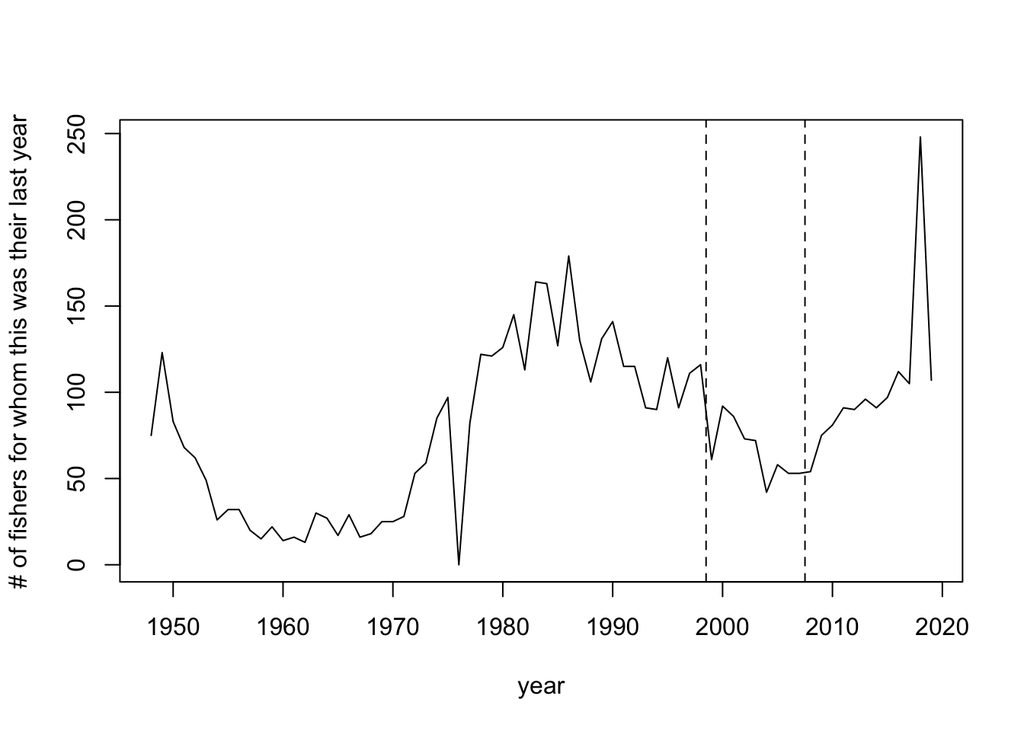

```r
{
plot(attrition_df$attritioning_fishers ~ attrition_df$year, ylab = '# of fishers for whom this was their last year', xlab = 'year', type = 'l')
abline(v = c(1998.5, 2007.5), col = 'black', lty = 2)
}
```

In fact we do see a spike in 1998 but it is similar in magnitude to spikes appearing throughout the mid-late 1990s and noticibly smaller than rates of attrition seen in the 1980s.

Attrition following enactment drops percipitously, perhaps anyone that was concerned about the BRFAs left before they were enacted. Attrition spikes the following year (2000) then slowly tapers off, pehaps as the BRFAs become the new normal. It could be really intersting to tie this data to other economic indicators (GDP, unemployment, etc.) but that’s outside the scope of analysis at this time.

Now lets examine attrition by experience level.

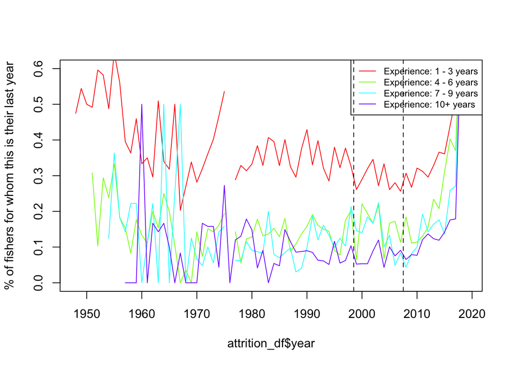

```r
color_pal = c('black', rainbow(length(experience_bins)))
plot.new()

{
plot((attrition_df$attritioning_fishers / attrition_df$total_fishers)  ~ attrition_df$year, pch = 19, col = 'black', type = 'n', ylim = c(0, .6), ylab = "% of fishers for whom this is their last year")
for(i in 1:(length(experience_bins))){
  lines((attrition_df[, i + 3 + length(experience_bins)] / attrition_df[ ,i + 2]) ~ attrition_df$year, col = color_pal[i+1])}
  legend('topright', col = c(rainbow(length(experience_bins))), legend = c( paste('Experience:', experience_bins[-length(experience_bins)], '-', experience_bins[2:length(experience_bins)] - 1, 'years', sep = " "), paste('Experience: ', experience_bins[length(experience_bins)], '+ years', sep = "")), lty = 1, cex = 0.75)
abline(v = c(1998.5, 2007.5), col = 'black', lty =  2)
}
```

So there do appear to be small spikes in attrition before implementation for all skill levels, with higher rates for fishers with the least experience (intuitively makes sense). There is not an obvious trend among experience groups for the 2008 restructuring.

### Modeling

Using the basic data we’ve aggregated lets try modeling this. What we want to know is if the attrition % is significantly higher prior to the years regulation goes into effect.

Using the % of fishers that attrition each year as our response variable, we will look to see if there is a significant effect for impacted years and if attrition rates change between management periods

For efficiency, we’ll limit our scope to the fishing years 1990 - 2018.

```r
## Limiting data scope
model_attrition_df = attrition_df[attrition_df$year >= 1990 & attrition_df$year <= 2018, ]

## Defining management regime
model_attrition_df$regime = 'before'
model_attrition_df$regime[model_attrition_df$year >= 1999] = 'implementation'
model_attrition_df$regime[model_attrition_df$year >= 2008] = 'revision'

## And we'll single out the specific years we're concerned with (the year immediately before impact)
model_attrition_df$implementation_impact = FALSE
model_attrition_df$implementation_impact[model_attrition_df$year == 1998] = TRUE

model_attrition_df$restructure_impact = FALSE
model_attrition_df$restructure_impact[model_attrition_df$year == 2007] = TRUE

## We also need to get experience columns into their own rows.
model_data_long = gather(data = model_attrition_df, key = experience_level, value = attrition_rate, "attritioning_level1-4":"attritioning_level10+", factor_key = TRUE)
model_data_long$attrition_rate = model_data_long$attritioning_fishers / model_data_long$total_fishers

## Creating a factor variable that also indicates year
model_data_long$fact_year = as.factor(model_data_long$year)

## Adjusting variable class
model_data_long$year = as.numeric(model_data_long$year)
model_data_long$attrition_rate = as.numeric(model_data_long$attrition_rate)
model_data_long$regime = as.factor(model_data_long$regime)
model_data_long$implementation_impact = as.logical(model_data_long$implementation_impact)
model_data_long$restructure_impact = as.logical(model_data_long$restructure_impact)
```

Before modeling we need to settle on an appropriate response structure.

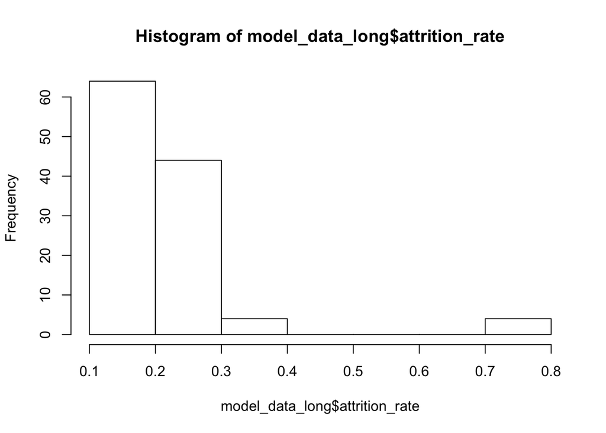

```r
hist(model_data_long$attrition_rate)
```

```r
range(model_data_long$attrition_rate)
```

```
## [1] 0.1296296 0.7209302
```

As should be expected, attrition rates range between 12 and 72 percent, with a theoretical minimum and maximum of 0 and 1. A beta distribution is defined 0<=x<=1 but so is a binomial model. At it’s heart, our data represents 0 = didn’t fish, 1 = fished, so the underlying structure at one point was binomial, but I’m not sure that it carries through.

```r
attrition_glm = glm(attrition_rate ~ experience_level*implementation_impact + experience_level*restructure_impact + (1|year), data = model_data_long)
summary(attrition_glm)
```

```
##
## Call:
## glm(formula = attrition_rate ~ experience_level * implementation_impact +
##     experience_level * restructure_impact + (1 | year), data = model_data_long)
##
## Deviance Residuals:
##      Min        1Q    Median        3Q       Max
## -0.09086  -0.04156  -0.02563   0.00808   0.50044
##
## Coefficients: (1 not defined because of singularities)
##                                                                    Estimate
## (Intercept)                                                       2.205e-01
## experience_levelattritioning_level4-7                            -1.924e-17
## experience_levelattritioning_level7-10                           -1.879e-17
## experience_levelattritioning_level10+                            -1.735e-17
## implementation_impactTRUE                                         5.630e-03
## restructure_impactTRUE                                           -7.368e-02
## 1 | yearTRUE                                                             NA
## experience_levelattritioning_level4-7:implementation_impactTRUE  -8.796e-17
## experience_levelattritioning_level7-10:implementation_impactTRUE -1.075e-16
## experience_levelattritioning_level10+:implementation_impactTRUE  -1.302e-16
## experience_levelattritioning_level4-7:restructure_impactTRUE     -1.843e-17
## experience_levelattritioning_level7-10:restructure_impactTRUE     3.658e-18
## experience_levelattritioning_level10+:restructure_impactTRUE     -9.993e-18
##                                                                  Std. Error
## (Intercept)                                                       2.095e-02
## experience_levelattritioning_level4-7                             2.963e-02
## experience_levelattritioning_level7-10                            2.963e-02
## experience_levelattritioning_level10+                             2.963e-02
## implementation_impactTRUE                                         1.109e-01
## restructure_impactTRUE                                            1.109e-01
## 1 | yearTRUE                                                             NA
## experience_levelattritioning_level4-7:implementation_impactTRUE   1.568e-01
## experience_levelattritioning_level7-10:implementation_impactTRUE  1.568e-01
## experience_levelattritioning_level10+:implementation_impactTRUE   1.568e-01
## experience_levelattritioning_level4-7:restructure_impactTRUE      1.568e-01
## experience_levelattritioning_level7-10:restructure_impactTRUE     1.568e-01
## experience_levelattritioning_level10+:restructure_impactTRUE      1.568e-01
##                                                                  t value
## (Intercept)                                                       10.523
```

[output cut: 35 more lines]

```
## experience_levelattritioning_level7-10:implementation_impactTRUE
## experience_levelattritioning_level10+:implementation_impactTRUE
## experience_levelattritioning_level4-7:restructure_impactTRUE
## experience_levelattritioning_level7-10:restructure_impactTRUE
## experience_levelattritioning_level10+:restructure_impactTRUE
## ---
## Signif. codes:  0 '***' 0.001 '**' 0.01 '*' 0.05 '.' 0.1 ' ' 1
##
## (Dispersion parameter for gaussian family taken to be 0.01185436)
##
##     Null deviance: 1.2541  on 115  degrees of freedom
## Residual deviance: 1.2329  on 104  degrees of freedom
## AIC: -171.94
##
## Number of Fisher Scoring iterations: 2
```

Nothing is immediately significant. Let’s see if there’s a better model in here

```r
options(na.action = "na.fail")
dredged_attrition_glm = dredge(attrition_glm)
```

```
## Fixed term is "(Intercept)"
```

```r
options(na.action = "na.omit")
print(dredged_attrition_glm)
```

```
## Global model call: glm(formula = attrition_rate ~ experience_level * implementation_impact +
##     experience_level * restructure_impact + (1 | year), data = model_data_long)
## ---
## Model selection table
##     (Int) exp_lvl impl_impc rst_impc exp_lvl:impl_impc exp_lvl:rst_impc df
## 1  0.2181                                                                2
## 5  0.2207                          +                                     3
## 3  0.2179                 +                                              3
## 7  0.2205                 +        +                                     4
## 2  0.2181       +                                                        5
## 6  0.2207       +                  +                                     6
## 4  0.2179       +         +                                              6
## 8  0.2205       +         +        +                                     7
## 22 0.2207       +                  +                                  +  9
## 12 0.2179       +         +                          +                   9
```

[output cut: 20 more lines]

So there are 2 models within 2 AICc values of the “best” model. They both include the effect of implementation or revision. Since dredge doesn’t provide any information regarding the significance of these terms, we’ll extract the models and look at their summaries.

```r
model2 = get.models(dredged_attrition_glm, subset = 2)
  summary(model2[[1]])
```

```
##
## Call:
## glm(formula = attrition_rate ~ restructure_impact + 1, data = model_data_long)
##
## Deviance Residuals:
##      Min        1Q    Median        3Q       Max
## -0.09106  -0.04177  -0.02583   0.00788   0.50024
##
## Coefficients:
##                         Estimate Std. Error t value Pr(>|t|)
## (Intercept)             0.220692   0.009827  22.458   <2e-16 ***
## restructure_impactTRUE -0.073878   0.052919  -1.396    0.165
## ---
## Signif. codes:  0 '***' 0.001 '**' 0.01 '*' 0.05 '.' 0.1 ' ' 1
##
## (Dispersion parameter for gaussian family taken to be 0.01081558)
##
##     Null deviance: 1.2541  on 115  degrees of freedom
## Residual deviance: 1.2330  on 114  degrees of freedom
## AIC: -191.93
##
## Number of Fisher Scoring iterations: 2
```

```r
model3 = get.models(dredged_attrition_glm, subset = 3)
  summary(model3[[1]])
```

```
##
## Call:
## glm(formula = attrition_rate ~ implementation_impact + 1, data = model_data_long)
##
## Deviance Residuals:
##      Min        1Q    Median        3Q       Max
## -0.08823  -0.04404  -0.02327   0.01071   0.50307
##
## Coefficients:
##                           Estimate Std. Error t value Pr(>|t|)
## (Intercept)               0.217860   0.009909  21.985   <2e-16 ***
## implementation_impactTRUE 0.008261   0.053364   0.155    0.877
## ---
## Signif. codes:  0 '***' 0.001 '**' 0.01 '*' 0.05 '.' 0.1 ' ' 1
##
## (Dispersion parameter for gaussian family taken to be 0.01099817)
##
##     Null deviance: 1.2541  on 115  degrees of freedom
## Residual deviance: 1.2538  on 114  degrees of freedom
## AIC: -189.99
##
## Number of Fisher Scoring iterations: 2
```

### Conclusion

Attrition rates have varried quite a bit both long term, and over the last 26 years. The more experienced a fisher is, the less likely they are to leave the fishery in a given year.

There is no evidence that fishers left the fishery at a rate higher than normal during years associated with the implementation or revision of the BRFAs.